# Analyse von Twitter-Daten

Twitter & Textmmining

Jan Kirenz

# 1 Einrichtung der Twitter-Schnittstelle

Zunächst müssen Sie sich bei Twitter [registrieren](https://apps.twitter.com). Falls Sie noch keinen Twitter-Account besitzen sollten, muss dieser zuvor erstellt werden.

1. Klicken Sie auf *Sign in*, um sich mit Ihrem Twitter-Account anzumnelden.
2. *Create App* auswählen und die Felder entsprechend den Vorgaben ausfüllen. Tragen Sie bei dem Feld Callback URL diesen Wert ein: http://127.0.0.1:1410 Sie finden die benötigten Zugangsdaten im Anschluss unter dem Reiter *Keys and Access Tokens*.
3. Unter dem Feld *Application Actions* können Sie nun den benötigten Consumer Key und das Consumer Secret erzeugen.

# 2 Zugriffe einrichten

Laden Sie nun die benötigten R-Pakete:

```r
library(rtweet)
library(tidyverse)
library(wordcloud)
library(tidytext)
library(reshape2)
library(textdata)
```

Setzen Sie Ihre eigenen Twitter-Zugriffsdaten ein und führen Sie die Zeilen aus (die bereits eingefügten Werte sind nur Platzhalter).

```r
# Name der App
appname <- ""

# API key
key <- ""

# API secret
secret <- ""

# Access token
access_token <- ""

# Access secret
access_secret <- ""
```

```r
twitter_token <- create_token(
  app = appname,
  consumer_key = key,
  consumer_secret = secret,
  access_token = access_token,
  access_secret = access_secret)
```

# 3 Daten aus Twitter importieren

## 3.1 Tweets

Nutzung der Funktion `rtweet::search_tweets()` um Daten aus Twitter zu importieren:

- q: Begriff, nach dem gesucht werden soll
- n: Anzahl der Tweets (maximal 18,000).

```r
tweets_df <- search_tweets(
                          q = "#Nike",
                          n = 10
                          )
```

```r
head(tweets_df, n = 4)
```

| user_id | status_id | created_at | screen_name | text | source | display_text_width | reply_to_status_id | reply_to_user_id | reply_to_screen_name | is_quote | is_retweet | favorite_count | retweet_count | quote_count | reply_count | hashtags | symbols | urls_url | urls_t.co | urls_expanded_url | media_url | media_t.co | media_expanded_url | media_type | ext_media_url | ext_media_t.co | ext_media_expanded_url | ext_media_type | mentions_user_id | … |
| --- | --- | --- | --- | --- | --- | --- | --- | --- | --- | --- | --- | --- | --- | --- | --- | --- | --- | --- | --- | --- | --- | --- | --- | --- | --- | --- | --- | --- | --- | --- |
| 1121144849678213121 | 1325901474090549248 | 2020-11-09 20:42:00 | Y22603005 | メルカリ\U0001f41d\n\nレディース•メンズ出品\U0001f92d\U0001f64c‼️\n#STUSSY #NIKE #adidas #グラミチ #ノースフェイス #パタゴニア #アニエスベー \n\n#ラストシンデレラ Blu-ray出品中\U0001f64c\U0001f941\U0001f3ba #ミュージカル #disney #CD #DVD #映画 \U0001f3ac\… | Twitter for iPhone | 139 | NA | NA | NA | FALSE | TRUE | 0 | 81 | NA | NA |  |  |  |  |  |  |  |  |  |  |  |  | NA |  | … |
| 1311295317116104707 | 1325901256632770563 | 2020-11-09 20:41:08 | AppleRTweet | With our Gucci Boxes, you are one step closer to your Gucci Room \U0001f60a\nhttps://t.co/DDEswOBlaG\n\n#mysteryboxes #Nike #Gucci #Supreme #Balenciaga #Bape #Dior #Converse #adidas #FearOfGod #OffWhi… |  | 140 | NA | NA | NA | FALSE | TRUE | 0 | 1 | NA | NA |  |  |  |  |  |  |  |  |  |  |  |  | NA |  | … |
| 1251811898548523011 | 1325901206829625344 | 2020-11-09 20:40:56 | dripdrawcom | With our Gucci Boxes, you are one step closer to your Gucci Room \U0001f60a\nhttps://t.co/DDEswOBlaG\n\n#mysteryboxes #Nike #Gucci #Supreme #Balenciaga #Bape #Dior #Converse #adidas #FearOfGod #OffWhi… | Twitter for Android | 274 | NA | NA | NA | FALSE | FALSE | 1 | 1 | NA | NA |  |  |  |  |  |  |  |  |  |  |  |  | NA |  | … |
| 162183961 | 1325900916692840452 | 2020-11-09 20:39:47 | Moonman989 | Nike SB Dunk Low Pro "Elephant" launches via an ONLINE RAFFLE which will be live until Tuesday 10th November 12:00GMT\n#hanon #nike #nikesb #nikedunk \nhttps://t.co/b5UiLdD3vd https://t.co/HbxbXEZuF5 | Twitter for iPhone | 140 | NA | NA | NA | FALSE | TRUE | 0 | 3 | NA | NA |  |  |  |  |  |  |  |  |  |  |  |  | NA |  | … |

## 3.2 Tweets ohne Retweets

Erneuter Import ohne Retweets

```r
tweets_df <- search_tweets("#Nike", n = 100,
                             include_rts = FALSE)
```

## 3.3 Users

Die Funktion `search_users()` kann verwendet werden um Nutzer anzuzeigen, die einen bestimmten # genutzt haben:

```r
users <- search_users("#Nike",
                      n = 10)

users
```

| user_id | status_id | created_at | screen_name | text | source | display_text_width | reply_to_status_id | reply_to_user_id | reply_to_screen_name | is_quote | is_retweet | favorite_count | retweet_count | quote_count | reply_count | hashtags | symbols | urls_url | urls_t.co | urls_expanded_url | media_url | media_t.co | media_expanded_url | media_type | ext_media_url | ext_media_t.co | ext_media_expanded_url | ext_media_type | mentions_user_id | … |
| --- | --- | --- | --- | --- | --- | --- | --- | --- | --- | --- | --- | --- | --- | --- | --- | --- | --- | --- | --- | --- | --- | --- | --- | --- | --- | --- | --- | --- | --- | --- |
| 415859364 | 1325782564599193600 | 2020-11-09 12:49:29 | Nike | @Letervis Dans ce cas, contacte notre service client en suivant ce lien : https://t.co/xZHtEnRWDz. | Sprinklr | 88 | 1325369789787893761 | 1007357706951450625 | Letervis | FALSE | FALSE | 0 | 0 | NA | NA |  |  |  |  |  |  |  |  |  |  |  |  | NA |  | … |
| 17351972 | 1325898865808125952 | 2020-11-09 20:31:38 | nikestore | @HYPEBEAST_PAT No date/time to confirm for when that option will be available on our Nike By You selection at the moment. Keep an eye out for updates, here: https://t.co/7paVbgUY43 | Sprinklr | 165 | 1325894036696215554 | 209101733 | HYPEBEAST_PAT | FALSE | FALSE | 0 | 0 | NA | NA |  |  |  |  |  |  |  |  |  |  |  |  | NA |  | … |
| 41147159 | 1325470755027607552 | 2020-11-08 16:10:28 | nikefootball | @MartynRushton Hey Martyn, the long sleeve version of the warm-up top is not currently available for purchase. Be sure to stay tuned to https://t.co/OuPOwhFhfz for possible future releases. | Sprinklr | 174 | 1325383934574727168 | 481078272 | MartynRushton | FALSE | FALSE | 0 | 0 | NA | NA |  |  |  |  |  |  |  |  |  |  |  |  | NA |  | … |
| 87770218 | 1319643092534751234 | 2020-10-23 14:13:25 | usnikefootball | You don't need to be a star to have a voice. #YouCantStopOurVoice\n\nLearn more: https://t.co/skpLvbw81r https://t.co/ougrmgjnm1 | Twitter for iPhone | 136 | NA | NA | NA | FALSE | TRUE | 0 | 1330 | NA | NA |  |  |  |  |  |  |  |  |  |  |  |  | NA |  | … |
| 217075136 | 1321304610007601154 | 2020-10-28 04:15:42 | nikediamond | The chase for history completed.\n\n#NikeDiamond #worldseries https://t.co/AsuHduhXDq | Twitter for iPhone | 59 | NA | NA | NA | FALSE | FALSE | 195 | 28 | NA | NA |  |  |  |  |  |  |  |  |  |  |  |  | NA |  | … |
| 19403548 | NA |  | NikeArgentina | NA | NA | NA | NA | NA | NA | FALSE | FALSE | NA | NA | NA | NA |  |  |  |  |  |  |  |  |  |  |  |  | NA |  | … |
| 40256448 | NA |  | NikeChile | NA | NA | NA | NA | NA | NA | FALSE | FALSE | NA | NA | NA | NA |  |  |  |  |  |  |  |  |  |  |  |  | NA |  | … |
| 561430822 | 1325801965146820609 | 2020-11-09 14:06:35 | nikelondon | @PtYoungers Hi Andrew, you can direct message us, we would need more details on code and the order itself. Let us know. | Sprinklr | 107 | 1325717963111010305 | 586641752 | PtYoungers | FALSE | FALSE | 0 | 0 | NA | NA |  |  |  |  |  |  |  |  |  |  |  |  | NA |  | … |
| 126142622 | 1018238339713884160 | 2018-07-14 20:58:32 | Nikecourt | No love lost.\n\nThe greatest athlete ever is the mother of all inspiration. #justdoit https://t.co/BUspq4xlxF | Twitter Web Client | 118 | NA | NA | NA | FALSE | TRUE | 0 | 2167 | NA | NA |  |  |  |  |  |  |  |  |  |  |  |  | NA |  | … |
| 92277809 | 695879602229612544 | 2016-02-06 08:00:00 | nikefootballita | Cambia team. Da oggi segui @nikefootball, l'unico account in cui seguire tutti i prossimi aggiornamenti. https://t.co/rqjuT2juOO | Sprinklr | 128 | NA | NA | NA | FALSE | FALSE | 11 | 5 | NA | NA |  |  |  |  |  |  |  |  |  |  |  |  | NA |  | … |

## 3.4 Standorte

[figure not shown]

```r
users %>%
  count(location, sort = TRUE) %>%
  mutate(location = reorder(location, n)) %>%
  top_n(n=10) %>%
  filter(location != "") %>%
  ggplot(aes(x = location, y = n)) +
  geom_col() +
  coord_flip() +
      labs(x = "Anzahl",
      y = "Standorte",
      title = "Twitter Nutzer - Standorte ")
```

# 4 Textmining

Die folgenden Inhalte orientieren sich an dem Buch [Text Mining with R](http://tidytextmining.com/index.html) von Julia Silge und David Robinson. Dort finden Sie ausführliche Erklärungen zu allen folgenden Schritten.

## 4.1 Tokenisierung

Zuerst wird jedes Wort als einzelne Zeile in einem Data Frame (hier als tweets) abgespeichert.

```r
library(tidytext)

tweets <-
  tweets_df %>%
  unnest_tokens(word, text)
```

## 4.2 Entfernung der Stoppwörter

Wir entfernen nun alle Stoppwörter (insb. Artikel und Konjunktionen), da diese für die Analysen irrelevant sind. Hinweis: alle nachfolgenden Analysen werden mit englischen Wörtern durchgeführt. Für die Analyse anderer Sprachen müssen entsprechend passende Stoppwörter und Lexikas verwendet werden.

```r
data(stop_words)

tweets <- tweets %>%
  anti_join(stop_words)
```

## 4.3 Analyse der Worthäufigkeiten

Nun könnne wir z.B. die häufigsten Worte untersuchen.

```r
tweets %>%
  count(word, sort = TRUE)
```

| word | n |
| --- | --- |
| t.co | 148 |
| https | 147 |
| nike | 128 |
| check | 31 |
| fashion | 31 |
| poshmark | 30 |
| shopmycloset | 30 |
| style | 30 |
| poshmarkapp | 29 |
| items | 28 |

[output cut: 961 more lines]

### 4.3.1 Erweiterung der Stoppwörter

Wie wir sehen, kommen immer noch Wörter vor, die wir nicht analysieren möchten (z.B. https, t.co). Diese werden nun in den Katalog der Stoppwörter mit aufgenommen. Wir erzeugen dafür einen neuen Katalog (custom_stop_words), welcher die ursprünglichen Stoppwörter (stop_words) und die von uns definierten Stoppwörter umfasst.

```r
custom_stop_words <- bind_rows(tibble(word = c("https", "t.co", "amp"),
                                          lexicon = c("custom", "custom", "custom")),
                               stop_words)

tweets <- tweets %>%
  anti_join(custom_stop_words)
```

### 4.3.2 Visualisierung der Worthäufigkeiten

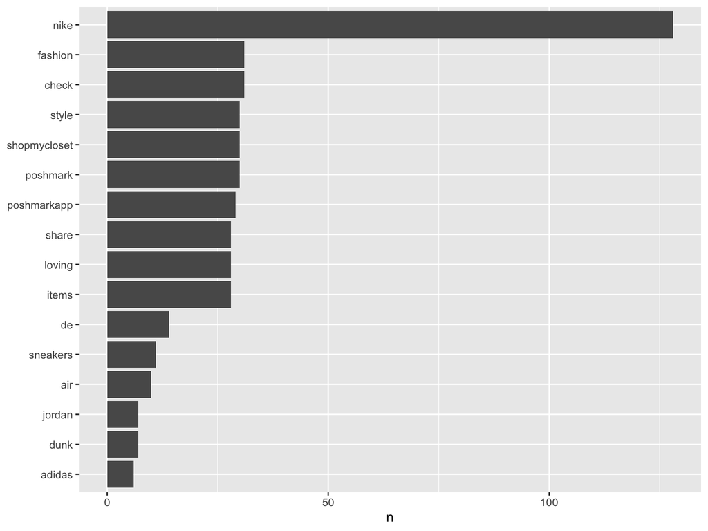

```r
tweets %>%
  count(word, sort = TRUE) %>%
  filter(n > 5) %>%
  mutate(word = reorder(word, n)) %>%
  ggplot(aes(word, n)) +
  geom_col() +
  xlab(NULL) +
  coord_flip()
```

## 4.4 Sentimentanalyse

### 4.4.1 Postitive Wörter

Nun nutzen wir das [NRC-Lexikon](http://saifmohammad.com/WebPages/NRC-Emotion-Lexicon.htm), um die positiven Wörter in den Tweets zu bestimmen.

```r
nrc_positive <- get_sentiments("nrc") %>%
  filter(sentiment == "positive")

tweets %>%
  inner_join(nrc_positive) %>%
  count(word, sort = TRUE)
```

| word | n |
| --- | --- |
| loving | 28 |
| share | 28 |
| basketball | 5 |
| pick | 2 |
| supreme | 2 |
| white | 2 |
| adapt | 1 |
| art | 1 |
| blossom | 1 |
| cash | 1 |

[output cut: 33 more lines]

### 4.4.2 Negative Wörter

Die gleiche Vorgehensweise könenn wir für negative Wörter nutzen.

```r
nrc_negative <- get_sentiments("nrc") %>%
  filter(sentiment == "negative")

tweets %>%
  inner_join(nrc_negative) %>%
  count(word, sort = TRUE)
```

| word | n |
| --- | --- |
| force | 3 |
| black | 1 |
| celebrity | 1 |
| challenge | 1 |
| cross | 1 |
| gore | 1 |
| gun | 1 |
| inter | 1 |
| lost | 1 |
| waste | 1 |

[output cut: 1 more lines]

### 4.4.3 Übersicht über positive und negative Wörter

Wir nutzen nun das [Bing-Lexikon](https://www.cs.uic.edu/~liub/FBS/sentiment-analysis.html) um sowohl positive als auch negative Wörter in einer Tabelle anzeigen zu lassen.

```r
bing_word_counts <- tweets %>%
  inner_join(get_sentiments("bing")) %>%
  count(word, sentiment, sort = TRUE) %>%
  ungroup()

bing_word_counts
```

| word | sentiment | n |
| --- | --- | --- |
| loving | positive | 28 |
| beloved | positive | 2 |
| fresh | positive | 2 |
| supreme | positive | 2 |
| adorer | positive | 1 |
| blossom | positive | 1 |
| champion | positive | 1 |
| classic | positive | 1 |
| cool | positive | 1 |
| easy | positive | 1 |

[output cut: 14 more lines]

### 4.4.4 Visualisierung der Sentimentanalyse mit Balkendiagrammen

Das Ergebnis kann bspw. mit ggplot2 visualisiert werden.

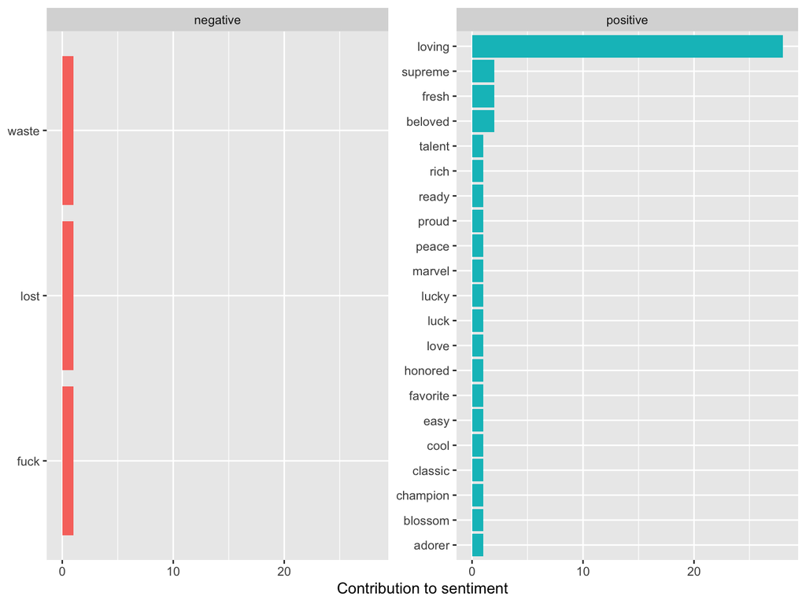

```r
bing_word_counts %>%
  group_by(sentiment) %>%
  top_n(10) %>%
  ungroup() %>%
  mutate(word = reorder(word, n)) %>%
  ggplot(aes(word, n, fill = sentiment)) +
  geom_col(show.legend = FALSE) +
  facet_wrap(~sentiment, scales = "free_y") +
  labs(y = "Contribution to sentiment",
       x = NULL) +
  coord_flip()
```

### 4.4.5 Visualisierung der Sentimentanalyse mit Wortwolken

Visualisierung mit einer Wortwolke.

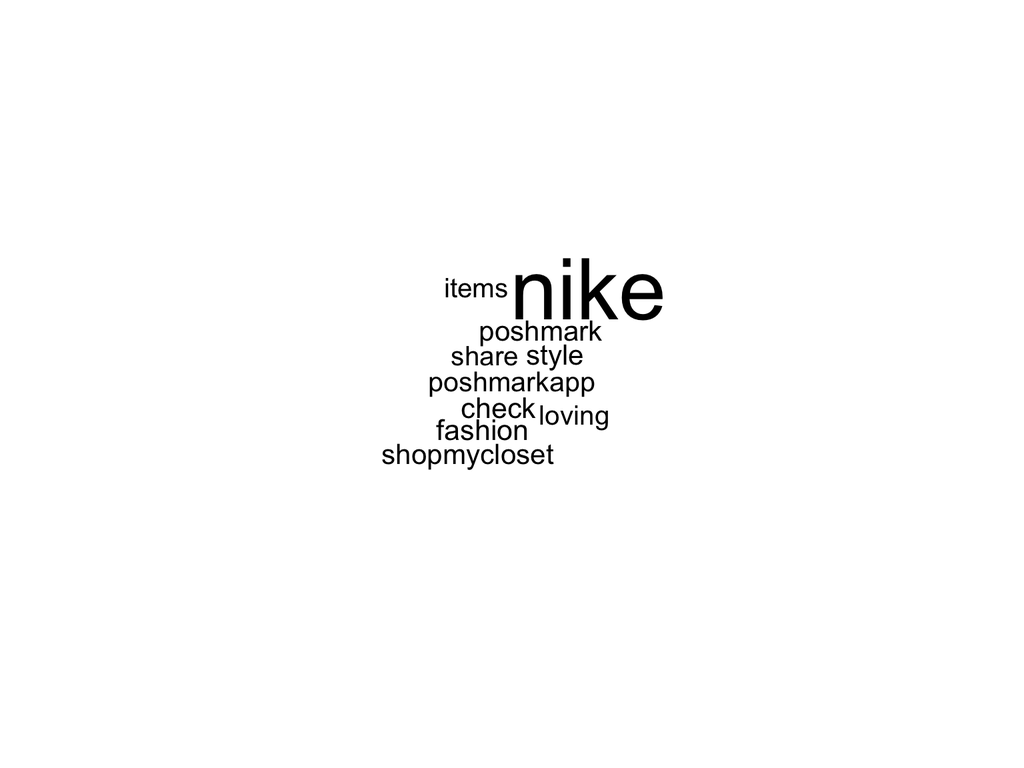

```r
tweets %>%
  anti_join(stop_words) %>%
  anti_join(custom_stop_words) %>%
  count(word) %>%
  with(wordcloud(word, n, max.words = 10))
```

Unterteilung der Wortwolke in negative und positive Wörter.

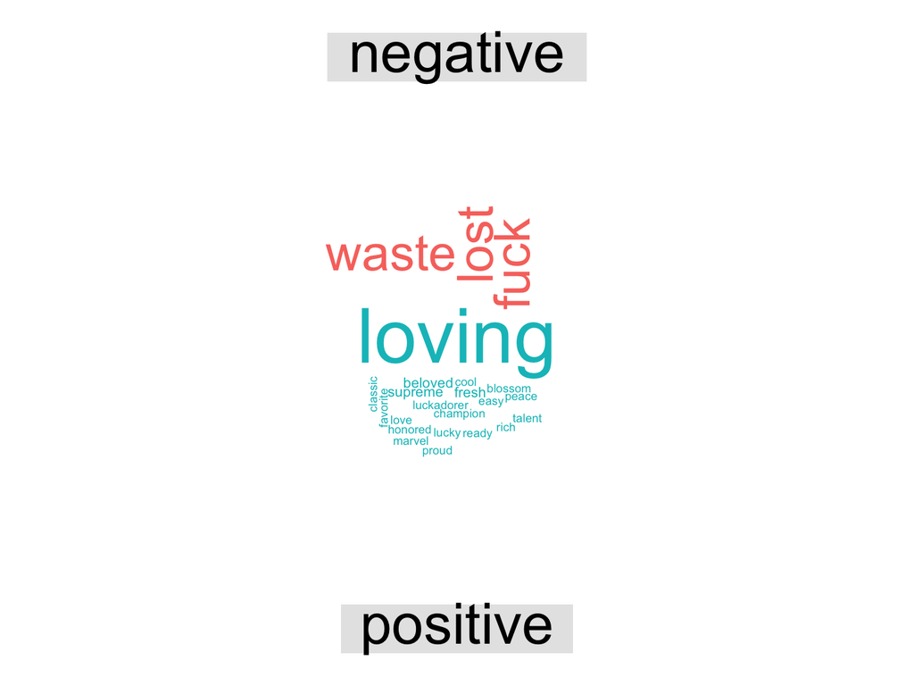

```r
tweets %>%
  inner_join(get_sentiments("bing")) %>%
  count(word, sentiment, sort = TRUE) %>%
  acast(word ~ sentiment, value.var = "n", fill = 0) %>%
  comparison.cloud(colors = c("#F8766D", "#00BFC4"),
                   max.words = 30)
```